# Self-Driving Car Engineer Nanodegree

## Project: Build a Traffic Sign Recognition Classifier

In this notebook, a template is provided for you to implement your functionality in stages which is required to successfully complete this project. If additional code is required that cannot be included in the notebook, be sure that the Python code is successfully imported and included in your submission, if necessary. Sections that begin with **'Implementation'** in the header indicate where you should begin your implementation for your project. Note that some sections of implementation are optional, and will be marked with **'Optional'** in the header.

In addition to implementing code, there will be questions that you must answer which relate to the project and your implementation. Each section where you will answer a question is preceded by a **'Question'** header. Carefully read each question and provide thorough answers in the following text boxes that begin with **'Answer:'**. Your project submission will be evaluated based on your answers to each of the questions and the implementation you provide.

> **Note:** Code and Markdown cells can be executed using the **Shift + Enter** keyboard shortcut. In addition, Markdown cells can be edited by typically double-clicking the cell to enter edit mode.

## Step 1: Dataset Exploration

Visualize the German Traffic Signs Dataset. This is open ended, some suggestions include: plotting traffic signs images, plotting the count of each sign, etc. Be creative!

The pickled data is a dictionary with 4 key/value pairs:

- features -> the images pixel values, (width, height, channels)
- labels -> the label of the traffic sign
- sizes -> the original width and height of the image, (width, height)
- coords -> coordinates of a bounding box around the sign in the image, (x1, y1, x2, y2). Based the original image (not the resized version).

```python
# Load pickled data

from sklearn.preprocessing import LabelBinarizer
from sklearn.model_selection import train_test_split
from collections import defaultdict
import matplotlib.pyplot as plt
import tensorflow as tf
import numpy as np
import random
import pickle
import math
import cv2

%matplotlib inline

# TODO: fill this in based on where you saved the training and testing data
training_file = "traffic-signs-data/train.p"
testing_file = "traffic-signs-data/test.p"

with open(training_file, mode='rb') as f:
    train = pickle.load(f)
with open(testing_file, mode='rb') as f:
    test = pickle.load(f)

X_train, y_train = train['features'], train['labels']
X_test, y_test = test['features'], test['labels']
```

```python
### To start off let's do a basic data summary.

# number of training examples
n_train = X_train.shape[0]

# number of testing examples
n_test = X_test.shape[0]

# what's the shape of an image?
image_shape = X_train[0].shape

# how many classes are in the dataset
n_classes = len(np.unique(y_train))

print("Number of training examples =", n_train)
print("Number of testing examples =", n_test)
print("Image data shape =", image_shape)
print("Number of classes =", n_classes)
```

```
Number of training examples = 39209
Number of testing examples = 12630
Image data shape = (32, 32, 3)
Number of classes = 43
```

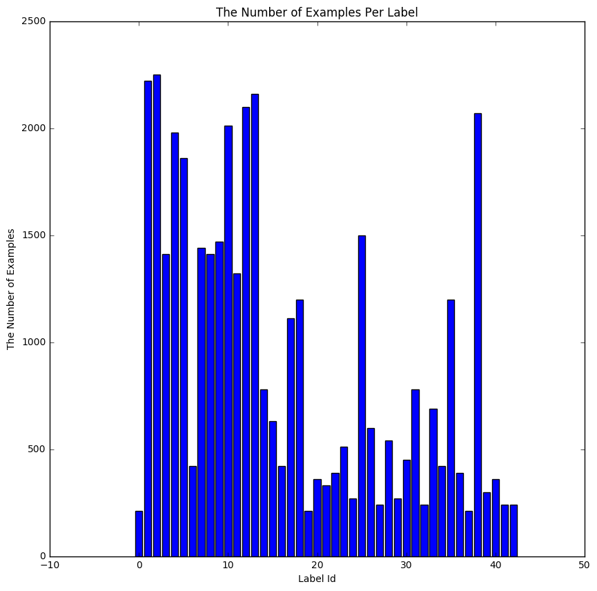

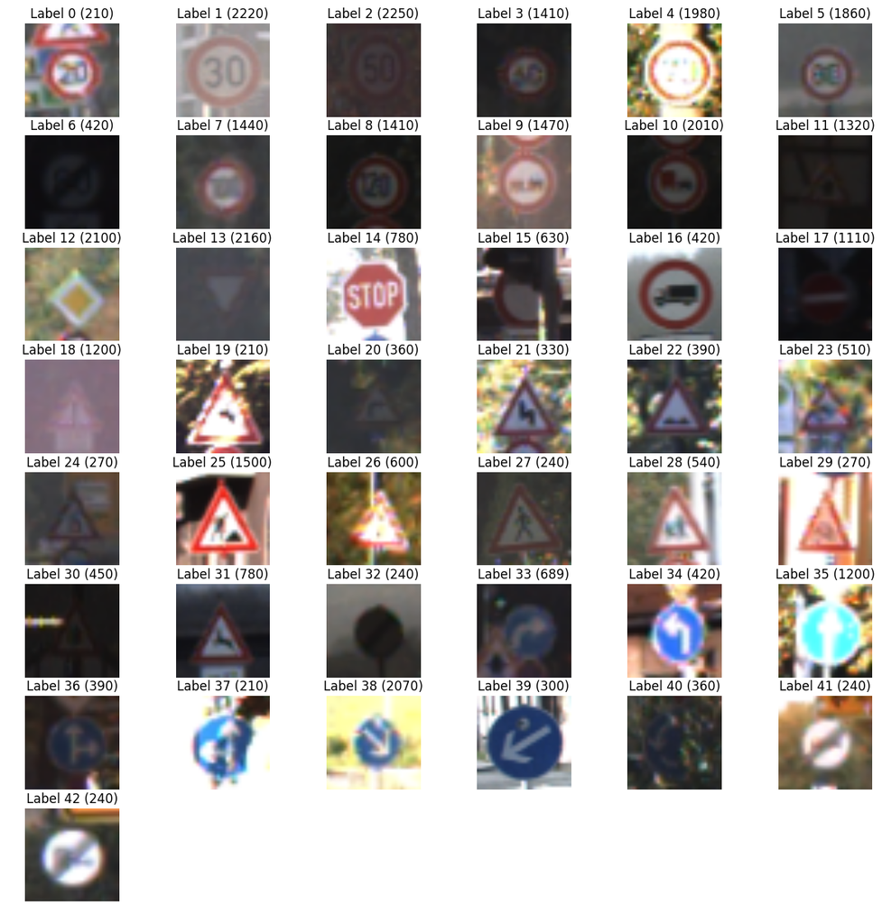

```python
### Data exploration visualization goes here.
### Feel free to use as many code cells as needed.
def generate_sign_dict(X_train, y_train):
    sign_count_dict = defaultdict(int)
    sign_image_dict = defaultdict(list)

    for i, x in enumerate(X_train):
        sign_count_dict[y_train[i]] += 1
        sign_image_dict[y_train[i]].append(x)

    return sign_count_dict, sign_image_dict

def show_class_count(sign_dict):
    plt.figure(figsize=(10, 10))
    plt.bar(range(len(sign_dict)), sign_dict.values(), align='center')
    plt.title('The Number of Examples Per Label')
    plt.xlabel('Label Id')
    plt.ylabel('The Number of Examples')
    plt.show()

def show_class_images(sign_image_dict):
    plt.figure(figsize=(15, 15))
    count = 0
    for key in sign_image_dict:
        plt.subplot(8, 6, count + 1)
        plt.axis('off')
        count += 1
        plt.title("Label {0} ({1})".format(key, len(sign_image_dict[key])))
        plt.imshow(sign_image_dict[key][0])

    plt.show()

sign_count_dict, sign_image_dict = generate_sign_dict(X_train, y_train)

# Plot the number of examples per label
show_class_count(sign_count_dict)

# plot an example image for every traffic sign
show_class_images(sign_image_dict)
```

From the above bar plot, we can see number of examples per label is highly unbalanced. If we pick a label and look at all its images

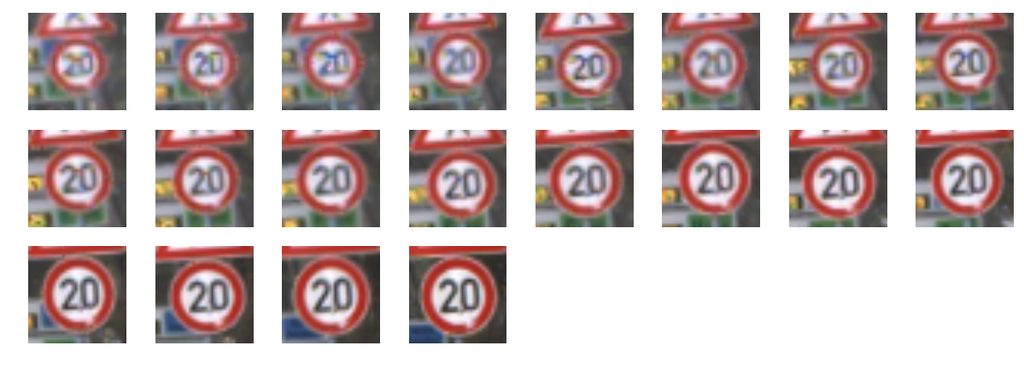

```python
def display_label_images(sign_image_dict, limit=20):
    """Display images of a specific label."""
    plt.figure(figsize=(15, 5))
    i = 1

    for i in range(min(limit, len(sign_image_dict[0]))):
        plt.subplot(3, 8, i + 1)  # 3 rows, 8 per row
        plt.axis('off')
        plt.imshow(sign_image_dict[0][i])
    plt.show()

display_label_images(sign_image_dict)
```

We can see the picture has different resolutions, and different lighting condition, but a good thing is all the traffic signs are centered in the images.

```python
def transform_image(img, ang_range, shear_range, trans_range):
    '''
    This function transforms images to generate new images.
    The function takes in following arguments,
    1- Image
    2- ang_range: Range of angles for rotation
    3- shear_range: Range of values to apply affine transform to
    4- trans_range: Range of values to apply translations over.

    A Random uniform distribution is used to generate different parameters for transformation
    '''
    # Rotation
    ang_rot = np.random.uniform(ang_range) - ang_range/2
    rows, cols, ch = img.shape
    Rot_M = cv2.getRotationMatrix2D((cols/2, rows/2), ang_rot, 1)

    # Translation
    tr_x = trans_range * np.random.uniform() - trans_range/2
    tr_y = trans_range * np.random.uniform() - trans_range/2
    Trans_M = np.float32([[1, 0, tr_x], [0, 1, tr_y]])

    # Shear
    pts1 = np.float32([[5, 5], [20,5],[5, 20]])

    pt1 = 5 + shear_range * np.random.uniform() - shear_range / 2
    pt2 = 20 + shear_range * np.random.uniform() - shear_range / 2

    pts2 = np.float32([[pt1, 5],[pt2, pt1],[5, pt2]])

    shear_M = cv2.getAffineTransform(pts1,pts2)

    img = cv2.warpAffine(img, Rot_M, (cols, rows))
    img = cv2.warpAffine(img, Trans_M, (cols, rows))
    img = cv2.warpAffine(img, shear_M, (cols, rows))

    return img
```

```python
max_count = max([sign_count_dict[key] for key in sign_count_dict])

def generate_jittered_images(limit=max_count):
    for key in sign_image_dict:
        print(key)
        prev_len = len(sign_image_dict[key])
        if prev_len >= limit:
            continue
        for _ in range(limit - prev_len):
            # get a random image for this label, and apply geometric transformation to the image
            r_source = int(random.random() * prev_len)
            r_image = sign_image_dict[key][r_source]
            transformed_img = transform_image(r_image, 20, 10, 5)
            np.append(X_train, transformed_img)
            np.append(y_train, key)

generate_jittered_images(1000)
print("Finished generating jittered images!")
```

```
0
1
2
3
4
5
6
7
8
9
10
11
12
13
14
15
16
17
18
19
20
21
22
23
24
25
26
27
28
29
30
31
32
33
34
35
36
37
38
39
40
41
42
Finished generating jittered images!
```

## Step 2: Design and Test a Model Architecture

Design and implement a deep learning model that learns to recognize traffic signs. Train and test your model on the [German Traffic Sign Dataset](http://benchmark.ini.rub.de/?section=gtsrb&subsection=dataset).

There are various aspects to consider when thinking about this problem:

- Your model can be derived from a deep feedforward net or a deep convolutional network.
- Play around preprocessing techniques (normalization, rgb to grayscale, etc)
- Number of examples per label (some have more than others).
- Generate fake data.

Here is an example of a [published baseline model on this problem](http://yann.lecun.com/exdb/publis/pdf/sermanet-ijcnn-11.pdf). It's not required to be familiar with the approach used in the paper but, it's good practice to try to read papers like these.

### Implementation

Use the code cell (or multiple code cells, if necessary) to implement the first step of your project. Once you have completed your implementation and are satisfied with the results, be sure to thoroughly answer the questions that follow.

```python
def normalize(image_data):
    """
    Normalize the image data with Min-Max scaling to a range of [0.1, 0.9]
    :param image_data: The image data to be normalized
    :return: Normalized image data
    """
    #gray = image_data.astype(float).sum(axis=-1) / 3.
    greyscale_min = 0.0
    greyscale_max = 255.0
    return (((image_data - greyscale_min)) / (greyscale_max - greyscale_min))

# normalization of features
X_train = normalize(X_train)
X_test = normalize(X_test)
```

```python
encoder = LabelBinarizer()
encoder.fit(y_train)
encoder.fit(y_test)
y_train = encoder.transform(y_train)
y_test = encoder.transform(y_test)
y_train = y_train.astype(np.float32)
y_test = y_test.astype(np.float32)
```

```python
### Generate data additional (if you want to!)
### and split the data into training/validation/testing sets here.
### Feel free to use as many code cells as needed.
X_train, X_valid, y_train, y_valid = train_test_split(
    X_train, y_train, test_size=0.33, random_state=832289)

print(X_train.shape)
print(X_valid.shape)
```

```
(26270, 32, 32, 3)
(12939, 32, 32, 3)
```

### Question 1

*Describe the techniques used to preprocess the data.*

**Answer:**

### Gray scale:

I didn't choose grayscale. According to this paper), some traffic signs, like "arrow", is more visible in color channels than grayscale. Also, color channels may be more informative than raw colors.

### One-hot encoding of the labels

Enode the labels to one-hot encoding, so it has 1 for its class id and 0 else where.

```python
### Generate data additional (if you want to!)
### and split the data into training/validation/testing sets here.
### Feel free to use as many code cells as needed.
```

### Question 2

*Describe how you set up the training, validation and testing data for your model. If you generated additional data, why?*

```python
### Define your architecture here.
### Feel free to use as many code cells as needed.
```

```python
# Parameters
batch_size = 128
training_epochs = 50
learning_rate=0.001

layer_width = {
    'layer_1': 32,
    'layer_2': 64,
    'layer_3': 128,
    'fully_connected': 512
}

# Store layers weight & bias
weights = {
    'layer_1': tf.Variable(tf.truncated_normal(
        [5, 5, 3, layer_width['layer_1']], stddev=0.2)),
    'layer_2': tf.Variable(tf.truncated_normal(
        [5, 5, layer_width['layer_1'], layer_width['layer_2']], stddev=0.2)),
    'layer_3': tf.Variable(tf.truncated_normal(
        [5, 5, layer_width['layer_2'], layer_width['layer_3']], stddev=0.2)),
    'fully_connected': tf.Variable(tf.truncated_normal(
        [4 * 4 * 128, layer_width['fully_connected']], stddev=0.2)),
    'out': tf.Variable(tf.truncated_normal(
        [layer_width['fully_connected'], n_classes], stddev=0.2))
}

biases = {
    'layer_1': tf.Variable(tf.zeros(layer_width['layer_1'])),
    'layer_2': tf.Variable(tf.zeros(layer_width['layer_2'])),
    'layer_3': tf.Variable(tf.zeros(layer_width['layer_3'])),
    'fully_connected': tf.Variable(tf.zeros(layer_width['fully_connected'])),
    'out': tf.Variable(tf.zeros(n_classes))
}

def conv2d(x, W, b, stride=1):
    x = tf.nn.conv2d(x, W, strides=[1, stride, stride, 1], padding='SAME')
    x = tf.nn.bias_add(x, b)
    return tf.nn.relu(x)


def maxpool2d(x, k=2):
    return tf.nn.max_pool(
        x,
        ksize=[1, k, k, 1],
        strides=[1, k, k, 1],
        padding='SAME')

# Create model
def conv_net(x, weights, biases, keep_prob):
    # Layer 1
    conv1 = conv2d(x, weights['layer_1'], biases['layer_1'])
    conv1 = maxpool2d(conv1)

    # Layer 2
    conv2 = conv2d(conv1, weights['layer_2'], biases['layer_2'])
    conv2 = maxpool2d(conv2)

    # Layer 3 - 7*7*64 to 4*4*128
    conv3 = conv2d(conv2, weights['layer_3'], biases['layer_3'])
    conv3 = maxpool2d(conv3)

    # Fully connected layer
    # Reshape conv2 output to fit fully connected layer input
    fc1 = tf.reshape(
        conv3,
        [-1, weights['fully_connected'].get_shape().as_list()[0]])

    fc1 = tf.add(
        tf.matmul(fc1, weights['fully_connected']),
        biases['fully_connected'])
    fc1 = tf.nn.relu(fc1)
    fc1 = tf.nn.dropout(fc1, keep_prob)

    out = tf.add(tf.matmul(fc1, weights['out']), biases['out'])
    return out

# tf Graph input
keep_prob = tf.placeholder(tf.float32) # probability to keep units
x = tf.placeholder(tf.float32, [None, 32, 32, 3])
#image = tf.reshape(x, [-1, 32, 32, 1])
y = tf.placeholder(tf.float32, [None, n_classes])
logits = conv_net(x, weights, biases, keep_prob)

# Define loss and optimizer
cost = tf.reduce_mean(tf.nn.softmax_cross_entropy_with_logits(logits, y))
optimizer = tf.train.AdamOptimizer(learning_rate=learning_rate).minimize(cost)

predicted_labels = tf.argmax(logits, 1)
# Test model
correct_prediction = tf.equal(predicted_labels, tf.argmax(y, 1))
# Calculate accuracy
accuracy = tf.reduce_mean(tf.cast(correct_prediction, tf.float32))

# Initializing the variables
init = tf.initialize_all_variables()
```

### Question 3

*What does your final architecture look like? (Type of model, layers, sizes, connectivity, etc.) For reference on how to build a deep neural network using TensorFlow, see Deep Neural Network in TensorFlow from the classroom.*

**Answer:**

- Type of Model: Multilayer Convolutional Network
- This multilayer convolutional network has three layers, alternating between convolutions and max pooling followed by a fully connected and output layer.
- The widths for each layer is: layer_width = { 'layer_1': 32, 'layer_2': 64, 'layer_3': 128, 'fully_connected': 512 } I basically followed the model in the LeNet lab.

```python
### Train your model here.
### Feel free to use as many code cells as needed.
```

```python
def eval_data():
    """
    Given a dataset as input returns the loss and accuracy.
    """
    # If dataset.num_examples is not divisible by BATCH_SIZE
    # the remainder will be discarded.
    # Ex: If BATCH_SIZE is 64 and training set has 55000 examples
    # steps_per_epoch = 55000 // 64 = 859
    # num_examples = 859 * 64 = 54976
    #
    # So in that case we go over 54976 examples instead of 55000.
    steps_per_epoch = len(X_valid) // batch_size
    num_examples = steps_per_epoch * batch_size
    total_acc, total_loss = 0, 0
    for step in range(steps_per_epoch):
        batch_x = X_valid[step * batch_size: (step + 1) * batch_size]
        batch_y = y_valid[step * batch_size: (step + 1) * batch_size]
        loss, acc = sess.run([cost, accuracy], feed_dict={x: batch_x, y: batch_y, keep_prob: 1.0})
        total_acc += (acc * batch_size)
        total_loss += loss

    return total_loss/num_examples, total_acc/num_examples
```

```python
# Launch the graph
with tf.Session() as sess:
    saver = tf.train.Saver()
    sess.run(init)
    # Training cycle

    for epoch in range(training_epochs):
        total_batch = int(math.ceil(len(X_train)/batch_size))
        # The training cycle
        for batch_i in range(total_batch):
            batch_x = X_train[batch_i * batch_size: (batch_i + 1) * batch_size]
            batch_y = y_train[batch_i * batch_size: (batch_i + 1) * batch_size]
            sess.run(optimizer, feed_dict={x: batch_x, y: batch_y, keep_prob: 0.5})

        # Check accuracy against Validation data
        val_loss, val_acc = eval_data()
        print("Epoch:", '%04d' % (epoch+1), "cost=",
              "{:.9f}".format(val_loss), "accuracy=", "{:.9f}".format(val_acc))
    print("Optimization Finished!")

    # Save the model
    saver.save(sess, "model.ckpt")

    print("Optimization Finished!")
    print(
        "Accuracy:",
        accuracy.eval({x: X_test, y: y_test, keep_prob: 1}))
```

```
Epoch: 0001 cost= 0.026338813 accuracy= 0.180770421
Epoch: 0002 cost= 0.022287450 accuracy= 0.278697401
Epoch: 0003 cost= 0.018081696 accuracy= 0.366413985
Epoch: 0004 cost= 0.015371037 accuracy= 0.431389233
Epoch: 0005 cost= 0.013837440 accuracy= 0.469136757
Epoch: 0006 cost= 0.012437500 accuracy= 0.509746287
Epoch: 0007 cost= 0.011407932 accuracy= 0.542465965
Epoch: 0008 cost= 0.009862967 accuracy= 0.603573639
Epoch: 0009 cost= 0.008677560 accuracy= 0.651531559
Epoch: 0010 cost= 0.007926039 accuracy= 0.686107673
Epoch: 0011 cost= 0.007143949 accuracy= 0.721844059
Epoch: 0012 cost= 0.006483242 accuracy= 0.734684406
Epoch: 0013 cost= 0.005717492 accuracy= 0.763304455
Epoch: 0014 cost= 0.005032151 accuracy= 0.794786510
Epoch: 0015 cost= 0.004542491 accuracy= 0.830213490
Epoch: 0016 cost= 0.003848466 accuracy= 0.847772277
Epoch: 0017 cost= 0.003254033 accuracy= 0.869740099
Epoch: 0018 cost= 0.002759895 accuracy= 0.894105817
Epoch: 0019 cost= 0.002536665 accuracy= 0.899752475
Epoch: 0020 cost= 0.002187743 accuracy= 0.907023515
Epoch: 0021 cost= 0.002050229 accuracy= 0.922416460
Epoch: 0022 cost= 0.001702925 accuracy= 0.932549505
Epoch: 0023 cost= 0.001457101 accuracy= 0.942295792
Epoch: 0024 cost= 0.001299185 accuracy= 0.949180074
Epoch: 0025 cost= 0.001122216 accuracy= 0.955445545
Epoch: 0026 cost= 0.001286694 accuracy= 0.950959158
Epoch: 0027 cost= 0.001026856 accuracy= 0.961943069
Epoch: 0028 cost= 0.000947390 accuracy= 0.964959777
Epoch: 0029 cost= 0.000885926 accuracy= 0.968440594
Epoch: 0030 cost= 0.000842977 accuracy= 0.968285891
Epoch: 0031 cost= 0.000790852 accuracy= 0.971689356
Epoch: 0032 cost= 0.000730610 accuracy= 0.974396658
Epoch: 0033 cost= 0.000574835 accuracy= 0.978960396
Epoch: 0034 cost= 0.000607851 accuracy= 0.978573639
Epoch: 0035 cost= 0.000635268 accuracy= 0.979037748
Epoch: 0036 cost= 0.000621778 accuracy= 0.978186881
Epoch: 0037 cost= 0.000634693 accuracy= 0.979192450
Epoch: 0038 cost= 0.000425363 accuracy= 0.984916460
Epoch: 0039 cost= 0.000482317 accuracy= 0.984607054
Epoch: 0040 cost= 0.000669234 accuracy= 0.975170173
Epoch: 0041 cost= 0.000579302 accuracy= 0.981048886
Epoch: 0042 cost= 0.000474462 accuracy= 0.985148515
Epoch: 0043 cost= 0.000482383 accuracy= 0.985225866
Epoch: 0044 cost= 0.000431912 accuracy= 0.985999381
Epoch: 0045 cost= 0.000352309 accuracy= 0.988397277
Epoch: 0046 cost= 0.000423382 accuracy= 0.985767327
Epoch: 0047 cost= 0.000499908 accuracy= 0.983756188
Epoch: 0048 cost= 0.000394222 accuracy= 0.987469059
Epoch: 0049 cost= 0.000486761 accuracy= 0.986850248
Epoch: 0050 cost= 0.000381967 accuracy= 0.987778465
Optimization Finished!
Optimization Finished!
Accuracy: 0.931987
```

### Question 4

*How did you train your model? (Type of optimizer, batch size, epochs, hyperparameters, etc.)*

**Answer:**

- Optimizer: Adam, with a learning rate of 0.001.
- batch_size = 128
- training_epochs = 50

### Question 5

*What approach did you take in coming up with a solution to this problem?*

**Answer:**

### Model: Multilayer ConvNets.

- We can't use linear model here because it is very limited, it can only represent additive relationship between the features. (I tried the linear model but it could only reach about 70% accurarcy.)
- Also, a deeper neural network is better than a wider two-layer neural networks regarding computational efficiency because it has less parameters(weights and bias). also deeper model can capture little phenomna in a hierarchical structure as mentioned in the course.
- I choose ConvNet because the statistical invariance attribute of ConvNet, in which we could share weights. Also multilayer ConvNet can learn small parts of the image to more complex parts when we get deeper in the network.

### Relu Activation

Relu Activation is applied at the end of each layer to get rid of the negative weigths and make the model non-linear to fit more complex problems.

### Maxpooling

Maxpooling applied after conv2d is to reduce the size of the input, and allow the neural network to focus on only the most important elements. It only retains the maximum value for each filterd area.

### Padding

I use padding in conv2d to keep the dimensionality consistent among layers.

### Dropout

Dropout is applied at the end of the fully connected layer to make the model more robust and prevent overfitting by randomly set half of the data to zero. It forced for the network to learn a redundant information of everything.

### Truncated Normal

- Truncated normal of the weights with a standard derivation is very important and it improves accurarcy dramatically. According to [TensorFlow truncated normal documentation](https://www.tensorflow.org/api_docs/python/constant_op/random_tensors#truncated_normal). For weights in each layer, we generated values follow a normal distribution with specified 0 mean and standard deviation 0.2, except that values whose magnitude is more than 2 standard deviations from the mean are dropped and re-picked.

### Why testing accurarcy is lower?

According to this [Github link](https://github.com/giladgressel/keras-traffic-signs/blob/master/data-set-merge-split-increases-test-accuracy.ipynb) Because the testing data set couldn't represent the training data set well, that's why I observed a drop of accurarcy when testing. The solution would be to merge the training data with testing data, and then split it in the same way into traing, validation, and testing data.

## Step 3: Test a Model on New Images

Take several pictures of traffic signs that you find on the web or around you (at least five), and run them through your classifier on your computer to produce example results. The classifier might not recognize some local signs but it could prove interesting nonetheless.

You may find `signnames.csv` useful as it contains mappings from the class id (integer) to the actual sign name.

### Implementation

Use the code cell (or multiple code cells, if necessary) to implement the first step of your project. Once you have completed your implementation and are satisfied with the results, be sure to thoroughly answer the questions that follow.

```python
### Load the images and plot them here.
### Feel free to use as many code cells as needed.

#You can load them using cv2's imread, resize to 32X32, and then use them as it is, or save them using pickle
import pandas as pd
import os
import matplotlib.image as mpimg

## Read the .csv file with the pandas read_csv method
pd.read_csv('signnames.csv')
```

|  | ClassId | SignName |
| --- | --- | --- |
| 0 | 0 | Speed limit (20km/h) |
| 1 | 1 | Speed limit (30km/h) |
| 2 | 2 | Speed limit (50km/h) |
| 3 | 3 | Speed limit (60km/h) |
| 4 | 4 | Speed limit (70km/h) |
| 5 | 5 | Speed limit (80km/h) |
| 6 | 6 | End of speed limit (80km/h) |
| 7 | 7 | Speed limit (100km/h) |
| 8 | 8 | Speed limit (120km/h) |
| 9 | 9 | No passing |
| 10 | 10 | No passing for vechiles over 3.5 metric tons |
| 11 | 11 | Right-of-way at the next intersection |
| 12 | 12 | Priority road |
| 13 | 13 | Yield |
| 14 | 14 | Stop |
| 15 | 15 | No vechiles |
| 16 | 16 | Vechiles over 3.5 metric tons prohibited |
| 17 | 17 | No entry |
| 18 | 18 | General caution |
| 19 | 19 | Dangerous curve to the left |
| 20 | 20 | Dangerous curve to the right |
| 21 | 21 | Double curve |
| 22 | 22 | Bumpy road |
| 23 | 23 | Slippery road |
| 24 | 24 | Road narrows on the right |
| 25 | 25 | Road work |
| 26 | 26 | Traffic signals |
| 27 | 27 | Pedestrians |
| 28 | 28 | Children crossing |
| 29 | 29 | Bicycles crossing |
| 30 | 30 | Beware of ice/snow |
| 31 | 31 | Wild animals crossing |
| 32 | 32 | End of all speed and passing limits |
| 33 | 33 | Turn right ahead |
| 34 | 34 | Turn left ahead |
| 35 | 35 | Ahead only |
| 36 | 36 | Go straight or right |
| 37 | 37 | Go straight or left |
| 38 | 38 | Keep right |
| 39 | 39 | Keep left |
| 40 | 40 | Roundabout mandatory |
| 41 | 41 | End of no passing |
| 42 | 42 | End of no passing by vechiles over 3.5 metric ... |

### Print the test images

```
[36, 13, 14, 25, 37, 0]
```

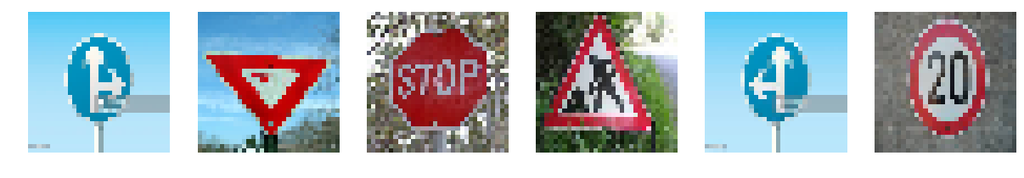

```python
import os
test_images = os.listdir("test_images/")
plt.figure(figsize=(15, 15))
sample_images = []
labels = []

topFive = tf.nn.top_k(tf.nn.softmax(logits), k=5, sorted=True, name=None)
sess = tf.Session()
init = tf.initialize_all_variables()
sess.run(init)

for i, img_name in enumerate(test_images):
    # read image
    img = mpimg.imread("test_images/" + img_name)
    img = cv2.resize(img, (32, 32))
    plt.subplot(1, len(test_images), i + 1)
    plt.imshow(img, interpolation='nearest')
    plt.axis('off')
    sample_images.append(normalize(img))
    labels.append(int(img_name[:-4]))

# convert to numpy array
sample_images = np.asarray(sample_images,dtype=np.float32)
print(labels)
```